# Milestone Report

John Klapp

December 18, 2019

## Week 2 Milestone Report

This milestone report described both what was done through the Week 1 and 2 work, and planning done towards the rest of the project.

### Week 2 Task 1: Getting and Cleaining the Data

In the interest of efficiency, and the philosophy of using the best tool for the job, the zip file was downloaded with wget, and unzipped using the OS native tool. From there, the three english files were evaluated using the code block below.

```r
scanTwitter = function() {
  con <- file("en_US.twitter.txt", "r")
  numLines = as.integer(0)
  maxLength = as.integer(0)
  hasHate = as.integer(0)
  hasLove = as.integer(0)
  hasPhrase = as.integer(0)

  while ( TRUE ) {
    line = readLines(con, n = 1)
    if ( length(line) == 0 ) {
      break
    }
    maxLength = max(maxLength,nchar(line))
    numLines = numLines + 1
    hasHate = hasHate + grepl("hate", line)
    hasLove = hasLove + grepl("love", line)
    hasPhrase = hasPhrase + grepl("A computer once beat me at chess, but it was no match for me at kickboxing",line)

    if(grepl("biostats",line)) {print(line)}
    #if (numLines > 1000) {break} # This just to read the first thousand to test
  }
  close(con)
}
```

This code gave the following results:

### Week 2 Task 2: Exploratory Data Analysis

This task was interleaved with task 1; the simple analysis above was acomplished before much data cleaning. Unsurprisingly, Twitter has the shortest lines due to the charachter limit. That the longest string of text was a blog post is also unsurprising; most blogs have neither an editor nor the requirement to fit in print. Both Twitter and the blogs had a love/hate ratio above 4, but the news is much less inclined to use the word “love” with a love/hate ratio of 3.4.

|  | Twitter | News | Blogs |
| --- | --- | --- | --- |
| maxLength | 213 | 5760 | 40835 |
| NumLines | 2360148 | 77259 | 899288 |
| hasHate | 22138 | 322 | 11098 |
| hasLove | 90956 | 1105 | 49167 |

### Week 2 Task 3: Modeling

The major objective of this task was to evaluate and explore ngram, the sequences of words in these collections of text. Many examples of the *tm* library include removing words like *the* and *and* as they don’t contribute largely to natural language processing. I chose to include them, as they are used in speech.

A challenge is that the computer I’m using can’t reasonably manipulate the entire dataset at once, so any word cleaning required (in R) copying the entire dataset, which in turn required a few gigabytes of swapping (pushing memory to/from the hard drive) and it died. So, for this, I chose to grab only 10% of the data to do the cleaning and extracting the ngrams (phrases) and count those.

```r
ngramTokenizer <- function(theCorpus, ngramCount) {
  ngramFunction <- NGramTokenizer(theCorpus,
                                  Weka_control(min = ngramCount, max = ngramCount,
                                               delimiters = " \\r\\n\\t.,;:\"()?!"))
  ngramFunction <- data.frame(table(ngramFunction))
  ngramFunction <- ngramFunction[order(ngramFunction$Freq,
                                       decreasing = TRUE),]
  colnames(ngramFunction) <- c("String","Count")
  ngramFunction
}
```

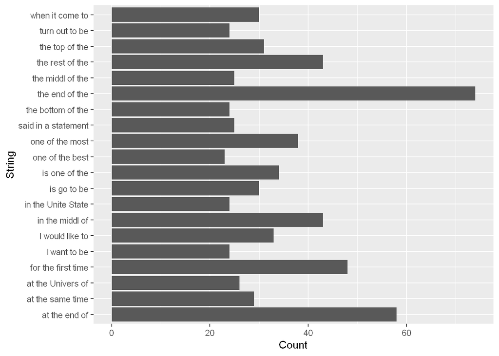

## Way Forward

My planned way forward is to develop a shiny app that takes user input from a text box, and looks for the most likely next word. Below are the big pieces I’m thinking about:

- First pass of the algorithm waits for a space bar to guess at next word
- When a 3 word string doesn’t strongly predict the following word, using only the last 2 words to predict the next word
- Once those are working, then extend the algorithm to pick the most likely next word as the next word is being typed (match the letters as they’re typed)

I appreciate your thoughts and feedback.